# Exploring Census and Election Data with Microsoft R Open

Fang Zhou

Sunday, April 24, 2016

# Introduction

`eechidna` (Exploring Election and Census Highly Informative Data Nationally for Australia) is an R package that makes it easy to look at the data from the 2011 Australian Census, and the 2013 Federal Election.

This vignette documents how to explore the 2011 Census and 2013 Federal Election data using Microsoft R Open.

```r
library(dplyr)
```

```r
library(ggplot2)
load("data/abs2011.rda")
load("data/aec2013.rda")
```

## 2011 Census Data

Let’s look at the data information of 2011 Census.

```r
#view data information
rxGetInfo(abs2011,getVarInfo=TRUE)
```

```
## Data frame: abs2011
## Number of observations: 150
## Number of variables: 35
## Variable information:
## Var 1: ID
##        150 factor levels: 101 102 103 104 105 ... 605 701 702 801 802
## Var 2: Electorate, Type: character
## Var 3: State, Type: character
## Var 4: Population, Type: integer, Low/High: (97705, 217497)
## Var 5: Area, Type: numeric, Low/High: (29.9057, 1583683.7000)
## Var 6: MedianIncome, Type: integer, Low/High: (375, 1062)
## Var 7: Unemployed, Type: numeric, Low/High: (3.2000, 10.1000)
## Var 8: Bachelor, Type: numeric, Low/High: (4.0302, 25.8565)
## Var 9: Postgraduate, Type: numeric, Low/High: (0.5463, 10.0155)
## Var 10: Christianity, Type: numeric, Low/High: (37.1757, 77.8469)
## Var 11: Catholic, Type: numeric, Low/High: (12.6490, 43.7854)
## Var 12: Buddhism, Type: numeric, Low/High: (0.3300, 24.6932)
## Var 13: Islam, Type: numeric, Low/High: (0.0809, 22.6662)
## Var 14: Judaism, Type: numeric, Low/High: (0.0128, 12.7742)
## Var 15: NoReligion, Type: numeric, Low/High: (7.5823, 35.9913)
## Var 16: Age00_04, Type: numeric, Low/High: (4.4805, 8.9252)
## Var 17: Age05_14, Type: numeric, Low/High: (4.5742, 16.8969)
## Var 18: Age15_19, Type: numeric, Low/High: (3.6099, 8.2410)
## Var 19: Age20_24, Type: numeric, Low/High: (3.9547, 14.5610)
## Var 20: Age25_34, Type: numeric, Low/High: (7.7329, 30.3276)
## Var 21: Age35_44, Type: numeric, Low/High: (11.3988, 18.3665)
## Var 22: Age45_54, Type: numeric, Low/High: (10.0117, 16.3301)
## Var 23: Age55_64, Type: numeric, Low/High: (7.9592, 15.4933)
## Var 24: Age65_74, Type: numeric, Low/High: (3.6529, 12.6490)
## Var 25: Age75_84, Type: numeric, Low/High: (1.1464, 7.9558)
## Var 26: Age85plus, Type: numeric, Low/High: (0.2850, 3.7268)
## Var 27: BornOverseas, Type: numeric, Low/High: (0.7357, 11.3956)
## Var 28: Indigenous, Type: numeric, Low/High: (0.1367, 42.7308)
## Var 29: EnglishOnly, Type: numeric, Low/High: (3.5878, 32.0482)
## Var 30: OtherLanguageHome, Type: numeric, Low/High: (1.7591, 67.2303)
## Var 31: Married, Type: numeric, Low/High: (21.3008, 45.2863)
## Var 32: DeFacto, Type: numeric, Low/High: (2.3593, 13.4315)
## Var 33: FamilyRatio, Type: numeric, Low/High: (44.5905, 52.1777)
## Var 34: Internet, Type: numeric, Low/High: (87.7344, 97.2676)
## Var 35: NotOwned, Type: numeric, Low/High: (69.9491, 90.5563)
```

```r
#transform column type
abs2011<-rxFactors(abs2011,
                   factorInfo=list(
                     Electorate=list(sortLevels=TRUE),
                     State=list(sortLevels=TRUE)
                                   ),
                   overwrite=TRUE)
```

```
## Rows Read: 150, Total Rows Processed: 150, Total Chunk Time: Less than .001 seconds
## Rows Read: 150, Total Rows Processed: 150, Total Chunk Time: Less than .001 seconds
```

```r
rxGetInfo(abs2011,getVarInfo=TRUE)$varInfo[c("Electorate","State")]
```

```
## $Electorate
## 150 factor levels: Adelaide Aston Ballarat Banks Barker ... Wentworth Werriwa Wide Bay Wills Wright
##
## $State
## 8 factor levels: ACT NSW NT QLD SA TAS VIC WA
```

Let’s look at some plots on the census data and the aggregated census data.

## Unemployment

```
## Rows Read: 150, Total Rows Processed: 150, Total Chunk Time: Less than .001 seconds
## Computation time: 0.000 seconds.
```

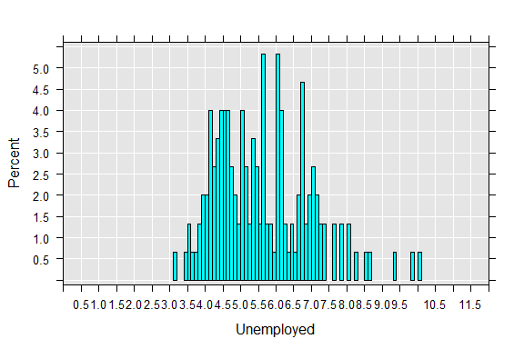

```r
#Unemployment
rxHistogram(~Unemployed,abs2011,numBreaks=50,histType="Percent",xAxisMinMax=c(0,12))
```

```
## Rows Read: 150, Total Rows Processed: 150, Total Chunk Time: 0.016 seconds
## Computation time: 0.016 seconds.
```

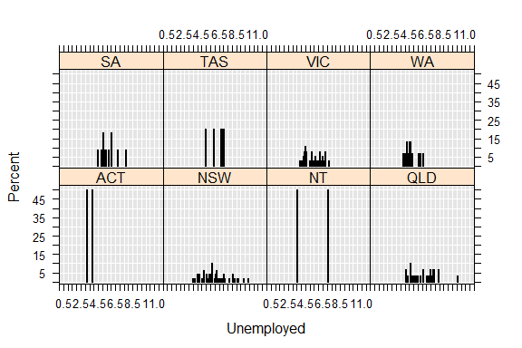

```r
rxHistogram(~Unemployed|State,abs2011,numBreaks=50,histType="Percent",xAxisMinMax=c(0,12))
```

```r
tmp<-rxCube(Unemployed~State,abs2011,means=TRUE)
```

```
## Rows Read: 150, Total Rows Processed: 150, Total Chunk Time: Less than .001 seconds
## Computation time: 0.000 seconds.
```

```r
result<-rxResultsDF(tmp)
result
```

```
##   State Unemployed Counts
## 1   ACT   3.550000      2
## 2   NSW   5.966667     48
## 3    NT   5.350000      2
## 4   QLD   6.116667     30
## 5    SA   5.700000     11
## 6   TAS   6.360000      5
## 7   VIC   5.351351     37
## 8    WA   4.700000     15
```

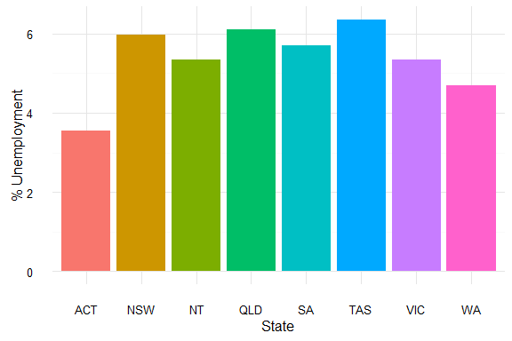

```r
ggplot(result,aes(x=State,y=Unemployed,fill=State))+
  geom_bar(stat="identity")+
  labs(x = "State",
     y = "% Unemployment") +
  theme_minimal() +
  theme(legend.position = "none")
```

## Income

```
## Rows Read: 150, Total Rows Processed: 150, Total Chunk Time: Less than .001 seconds
## Computation time: 0.000 seconds.
```

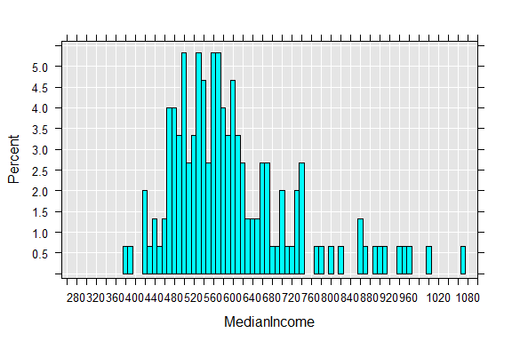

```r
#Income
rxHistogram(~MedianIncome,abs2011,numBreaks=50,histType="Percent",xAxisMinMax=c(250,1100))
```

```
## Rows Read: 150, Total Rows Processed: 150, Total Chunk Time: 0.016 seconds
## Computation time: 0.016 seconds.
```

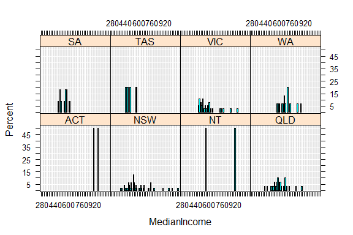

```r
rxHistogram(~MedianIncome|State,abs2011,numBreaks=50,histType="Percent",xAxisMinMax=c(250,1100))
```

```r
tmp<-rxCube(MedianIncome~State,abs2011,means=TRUE)
```

```
## Rows Read: 150, Total Rows Processed: 150, Total Chunk Time: Less than .001 seconds
## Computation time: 0.000 seconds.
```

```r
result<-rxResultsDF(tmp)
result
```

```
##   State MedianIncome Counts
## 1   ACT     918.5000      2
## 2   NSW     583.6042     48
## 3    NT     730.0000      2
## 4   QLD     597.3667     30
## 5    SA     537.2727     11
## 6   TAS     501.0000      5
## 7   VIC     571.9730     37
## 8    WA     669.0000     15
```

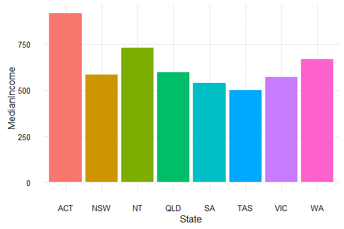

```r
ggplot(result,aes(x=State,y=MedianIncome,fill=State))+
  geom_bar(stat="identity")+
  labs(x = "State",
       y = "MedianIncome") +
  theme_minimal() +
  theme(legend.position = "none")
```

## Education

```
## Rows Read: 150, Total Rows Processed: 150, Total Chunk Time: 0.003 seconds
## Computation time: 0.006 seconds.
```

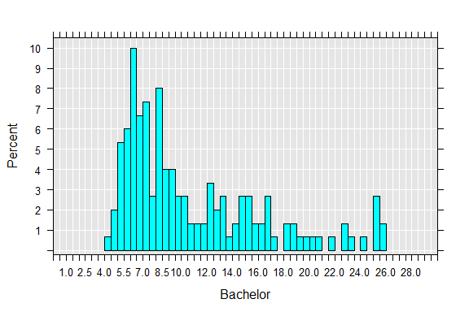

```r
#Education
rxHistogram(~Bachelor,abs2011,numBreaks=50,histType="Percent",xAxisMinMax=c(0,30))
```

```
## Rows Read: 150, Total Rows Processed: 150, Total Chunk Time: Less than .001 seconds
## Computation time: 0.016 seconds.
```

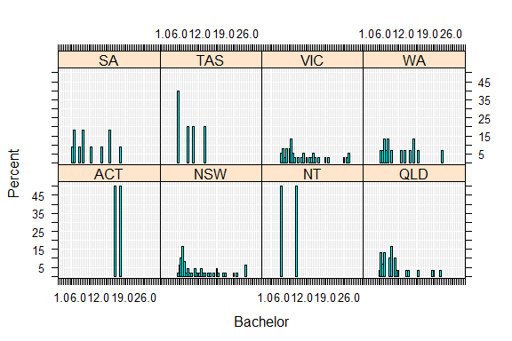

```r
rxHistogram(~Bachelor|State,abs2011,numBreaks=50,histType="Percent",xAxisMinMax=c(0,30))
```

```r
tmp<-rxCube(Bachelor~State,abs2011,means=TRUE)
```

```
## Rows Read: 150, Total Rows Processed: 150, Total Chunk Time: Less than .001 seconds
## Computation time: 0.015 seconds.
```

```r
result<-rxResultsDF(tmp)
result
```

```
##   State  Bachelor Counts
## 1   ACT 17.290984      2
## 2   NSW 11.197686     48
## 3    NT  7.999001      2
## 4   QLD  9.333661     30
## 5    SA  9.638991     11
## 6   TAS  8.389103      5
## 7   VIC 12.042286     37
## 8    WA 10.608675     15
```

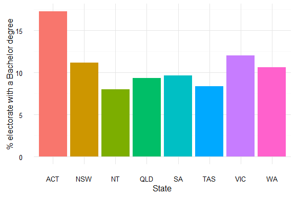

```r
ggplot(result,aes(x=State,y=Bachelor,fill=State))+
  geom_bar(stat="identity")+
  labs(x = "State",
       y = "% electorate with a Bachelor degree") +
  theme_minimal() +
  theme(legend.position = "none")
```

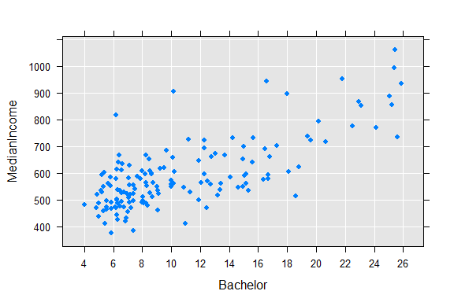

```r
rxLinePlot(MedianIncome~Bachelor,abs2011,type="p")
```

```r
tmp<-rxCube(Postgraduate~State,abs2011,means=TRUE)
```

```
## Rows Read: 150, Total Rows Processed: 150, Total Chunk Time: Less than .001 seconds
## Computation time: 0.000 seconds.
```

```r
result<-rxResultsDF(tmp)
result
```

```
##   State Postgraduate Counts
## 1   ACT     7.149185      2
## 2   NSW     3.355079     48
## 3    NT     2.040738      2
## 4   QLD     2.177014     30
## 5    SA     2.284253     11
## 6   TAS     1.924869      5
## 7   VIC     3.190359     37
## 8    WA     2.350337     15
```

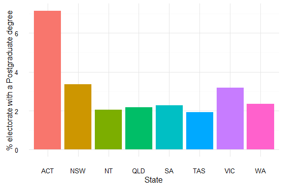

```r
ggplot(result,aes(x=State,y=Postgraduate,fill=State))+
  geom_bar(stat="identity")+
  labs(x = "State",
       y = "% electorate with a Postgraduate degree") +
  theme_minimal() +
  theme(legend.position = "none")
```

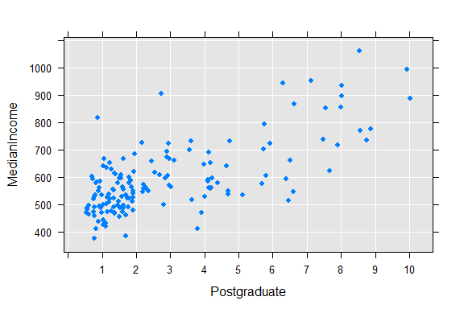

```r
rxLinePlot(MedianIncome~Postgraduate,abs2011,type="p")
```

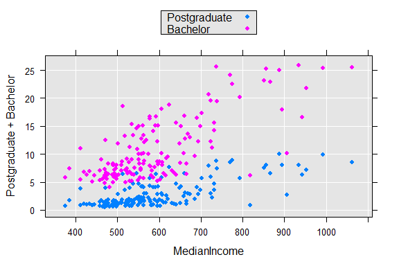

```r
rxLinePlot(Postgraduate+Bachelor~MedianIncome,abs2011,type="p")
```

## Internet

```
## Rows Read: 150, Total Rows Processed: 150, Total Chunk Time: Less than .001 seconds
## Computation time: 0.000 seconds.
```

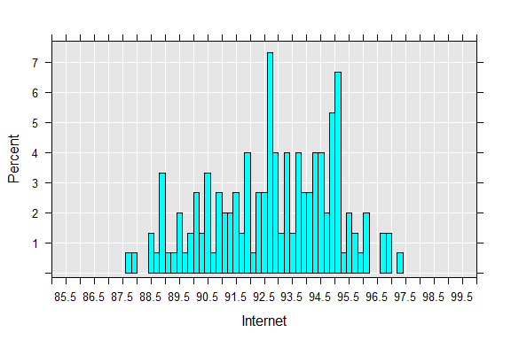

```r
#Internet
rxHistogram(~Internet,abs2011,numBreaks=50,histType="Percent",xAxisMinMax=c(85,100))
```

```
## Rows Read: 150, Total Rows Processed: 150, Total Chunk Time: Less than .001 seconds
## Computation time: 0.016 seconds.
```

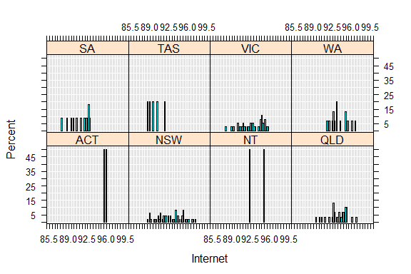

```r
rxHistogram(~Internet|State,abs2011,numBreaks=50,histType="Percent",xAxisMinMax=c(85,100))
```

## 2013 Federal Election Data

We have two election datasets. One is called aec2013, and each row represents a particular canditate at a particular polling place. We can and can inspect this data like this:

```r
#view data information of 2013 election data
rxGetInfo(aec2013,getVarInfo=TRUE)
```

```
## Data frame: aec2013
## Number of observations: 82398
## Number of variables: 27
## Variable information:
## Var 1: ID, Type: integer, Low/High: (101, 316)
## Var 2: Electorate, Type: character
## Var 3: PollingPlaceID, Type: integer, Low/High: (1, 65758)
## Var 4: PollingPlace, Type: character
## Var 5: CandidateID, Type: integer, Low/High: (999, 25040)
## Var 6: Surname, Type: character
## Var 7: GivenNm, Type: character
## Var 8: BallotPosition, Type: integer, Low/High: (1, 999)
## Var 9: Elected, Type: character
## Var 10: HistoricElected, Type: character
## Var 11: PartyAb, Type: character
## Var 12: PartyNm, Type: character
## Var 13: OrdinaryVotes, Type: integer, Low/High: (0, 8119)
## Var 14: Swing, Type: numeric, Low/High: (-114.2900, 100.0000)
## Var 15: State, Type: character
## Var 16: DivisionNm.y, Type: character
## Var 17: PollingPlaceTypeID, Type: integer, Low/High: (1, 5)
## Var 18: PremisesNm, Type: character
## Var 19: PremisesAddress1, Type: character
## Var 20: PremisesAddress2, Type: character
## Var 21: PremisesAddress3, Type: character
## Var 22: PremisesSuburb, Type: character
## Var 23: PremisesStateAb, Type: character
## Var 24: PremisesPostCode, Type: integer, Low/High: (800, 7470)
## Var 25: Latitude, Type: numeric, Low/High: (-43.4341, 0.0000)
## Var 26: Longitude, Type: numeric, Low/High: (0.0000, 167.9583)
## Var 27: uid, Type: character
```

```r
#transform column type
aec2013<-rxFactors(aec2013,
                   factorInfo=list(
                     Electorate=list(sortLevels=TRUE),
                     PollingPlace=list(sortLevels=TRUE),
                     Elected=list(sortLevels=TRUE),
                     HistoricElected=list(sortLevels=TRUE),
                     PartyAb=list(sortLevels=TRUE),
                     PartyNm=list(sortLevels=TRUE),
                     State=list(sortLevels=TRUE),
                     DivisionNm.y=list(sortLevels=TRUE)
                                   ),
                   overwrite=TRUE)
```

```
## Rows Read: 82398, Total Rows Processed: 82398, Total Chunk Time: 0.391 seconds
## Rows Read: 82398, Total Rows Processed: 82398, Total Chunk Time: 0.032 seconds
```

```r
rxGetInfo(aec2013,getVarInfo=TRUE)$varInfo[c("PollingPlace","Elected","PartyNm")]
```

```
## $PollingPlace
## 8226 factor levels: AVEO Durack Abbotsbury Abbotsford Abbotsham Aberdare ... Zeehan Zetland Zetland South Zillmere Zillmere North
##
## $Elected
## 2 factor levels: N Y
##
## $PartyNm
## 40 factor levels: A.F.N.P.P. Animal Justice Party Australia First Party Australian Christians Australian Democrats ... Stable Population Party The Greens The Nationals Uniting Australia Party Voluntary Euthanasia Party
```

We can see that the data contains 82398 rows and 27 columns.

The other dataset is aec2013_electorate and is the results of the election aggregated for each electorate. Each row represents a particular candidate at a particular electorate.

We obtained these data from http://results.aec.gov.au/ . This package incorporates data that is © Commonwealth of Australia (Australian Electoral Commission) 2016.

We can summarise the data to discover some basic details about the election. Here we can find the total number of ordinary votes (not including postal votes, etc.) for each party:

```r
tmp<-rxCube(OrdinaryVotes~PartyNm,aec2013,means=FALSE)
```

```
## Rows Read: 82398, Total Rows Processed: 82398, Total Chunk Time: Less than .001 seconds
## Computation time: 0.015 seconds.
```

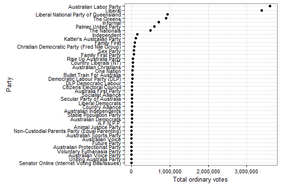

```r
total_votes_for_parties<-rxResultsDF(tmp)
library(ggplot2)
library(scales)
ggplot(total_votes_for_parties, aes(reorder(PartyNm, OrdinaryVotes), OrdinaryVotes )) +
  geom_point() +
  coord_flip() +
  scale_y_continuous(labels = comma) +
  theme_bw() +
  ylab("Total ordinary votes") +
  xlab("Party") +
  theme(text = element_text(size=10))
```

```r
tmp<-rxCrossTabs(OrdinaryVotes~Electorate:PartyNm,aec2013)
```

```
## Rows Read: 82398, Total Rows Processed: 82398, Total Chunk Time: Less than .001 seconds
## Computation time: 0.015 seconds.
```

```r
result <- rxResultsDF(tmp,output="sums")
result[1:6,1:3]
```

```
##   Electorate PartyNm.A.F.N.P.P. PartyNm.Animal.Justice.Party
## 1   Adelaide                  0                            0
## 2      Aston                  0                            0
## 3   Ballarat                  0                            0
## 4      Banks                  0                            0
## 5     Barker                  0                            0
## 6     Barton                  0                            0
```

[figure not shown]

```r
colnames(result)[-1]<-substring(colnames(result[,-1]),9)
cellnote1<-matrix(as.character(data.matrix(round(result[,-1]))),
                  byrow=FALSE,nrow=dim(result)[1])
library(gplots)
par(oma=c(0.1,0.1,0.1,0.1))
heatmap.2(data.matrix(result[,-1]),
          labRow=result[,1], col=cm.colors(255),
          trace='none',dendrogram ="none",
          #cellnote=cellnote1,notecex=0.4,notecol="black",
          na.color=par("bg"))
```